# DSA 495 601 Project Milestone 6

# Introduction

For Milestone 6, you will test your selected learner from Milestone 5 on your held-out test set. This milestone represents the culmination of your predictive modeling project, where you evaluate how well your model generalizes to completely unseen data.

**Your goals:**

1. Apply your selected learner to the test set
2. Compare test performance to validation performance
3. Evaluate discrimination and calibration on test data
4. Assess fairness metrics on the test population
5. Provide final recommendations for model deployment

**Important notes:**

- The test set should only be used once - this is your final evaluation
- All coding you will need to modify or expand are marked with @TODO
- Answer all questions marked with @TODO

After completing all sections, knit to HTML, then download and print/save as PDF using this naming convention: `DSC495_601_FA25_Milestone6_unityID.pdf`

**Due date:** November 13 11:45 a.m. ET

# Setup

This section loads all necessary files and configures your R environment for model testing.

```r
# Set random seed for reproducibility
seed <- 2024

# Configure notebook settings
knitr::opts_chunk$set(
  cache = FALSE,      # Don't cache results
  warning = FALSE,    # Suppress warnings
  message = FALSE,    # Suppress messages
  fig.width = 8,
  fig.height = 7
)

# Load helper scripts with custom functions
# These must be in your R/ subdirectory
source("/share/dsa495601f25/templates/R/packages.R")
source("/share/dsa495601f25/templates/R/learner_training.R")
source("/share/dsa495601f25/templates/R/learner_training_helpers.R")
source("/share/dsa495601f25/templates/R/equity_metrics.R")
source("/share/dsa495601f25/templates/R/performance_metrics.R")
source("/share/dsa495601f25/templates/R/plots_updated.R")

# Load your processed data from Milestone 3
trainDat <- readRDS(paste0(params$my_path, "trainDat_banking.rds"))
  # @TODO: Verify filename matches Milestone 3
testDat  <- readRDS(paste0(params$my_path, "testDat_banking.rds"))
  # @TODO: Verify filename matches Milestone 3

# Load learner specifications from Milestone 4
learnerSpec <- readRDS(paste0(params$my_path, "learnerSpec_banking.rds"))
  # @TODO: Verify filename matches Milestone 4

# Load preprocessing recipes from Milestone 4
recipes <- readRDS(paste0(params$my_path, "recipes_banking.rds"))
  # @TODO: Verify filename matches Milestone 4
mainRecipes <- readRDS(paste0(params$my_path, "recipe_main_banking.rds"))
  # @TODO: Verify filename matches Milestone 4

# Load validation results from Milestone 5
trainResults <- readRDS(paste0(params$my_path, "validateLearnersResults_banking.rds"))
  # @TODO: Verify filename matches Milestone 5

# Extract key components
trainMetrics <- trainResults$learnersMetrics
trainPredProbs <- trainResults$predProbs


# Verify everything loaded correctly
cat("\nData verification:\n")
```

```
##
## Data verification:
```

```r
cat("Training data:", nrow(trainDat), "rows,", ncol(trainDat), "columns\n")
```

```
## Training data: 31647 rows, 85 columns
```

```r
cat("Testing data:", nrow(testDat), "rows,", ncol(testDat), "columns\n")
```

```
## Testing data: 13564 rows, 85 columns
```

```r
cat("Selected learner:", trainResults$modelResults$learnerName[[1]], "\n")
```

```
## Selected learner: glm_predSet_bm
```

```r
cat("Selected threshold(s):", trainResults$selectedThreshold, "\n")
```

```
## Selected threshold(s): 0.25
```

```r
cat("Outcome variable:", learnerSpec$outcomeName, "\n")
```

```
## Outcome variable: y_binary
```

# 1. Data consistency checks

Before applying your model to the test set, we need to verify that the test data is compatible with your trained model.

## 1.1 Feature availability check

Verify that all predictors used in training are present in the test set.

```r
# Extract predictors used in the selected model
outcome <- learnerSpec$outcomeName
learnerName <- trainResults$modelResults$learnerName[[1]]
model_vars <- colnames(trainResults$modelFits[[learnerName]]$pre$mold$predictors)

# Check for missing predictors in test set
missing_in_test <- setdiff(model_vars, names(testDat))

# Display results
if (length(missing_in_test) == 0) {
  cat("✓ All required predictors are present in the test dataset.\n")
} else {
  cat("⚠ WARNING: The following predictors are missing from the test set:\n")
  cat(paste("-", missing_in_test, collapse = "\n"), "\n")
}
```

```
## ✓ All required predictors are present in the test dataset.
```

```r
cat("\nNumber of predictors in model:", length(model_vars), "\n")
```

```
##
## Number of predictors in model: 7
```

## 1.2 Distribution comparison

Compare the distributions of predictors between training and test sets.

```r
# @TODO: Select 3-5 important predictors from your model to examine
key_predictors <- model_vars  # You can keep this as model_vars if you don't have a large set of predictor
                              # Otherwise change model_vars to something like c("age_std","prev_success","balance_std") - the most important features

# Filter to only predictors that exist in both datasets
key_predictors <- intersect(key_predictors, model_vars)

if (length(key_predictors) > 0) {
  # Create comparison summaries
  cat("=== Distribution Comparison for Key Predictors ===\n\n")

  for (pred in key_predictors) {
    cat("Variable:", pred, "\n")

    if (is.numeric(trainDat[[pred]])) {
      # Numeric variable comparison
      print(summary(trainDat[[pred]]))
      print(summary(testDat[[pred]]))

    } else {
      # Categorical variable comparison
      train_table <- table(trainDat[[pred]]) / nrow(trainDat)
      test_table <- table(testDat[[pred]]) / nrow(testDat)

      cat("  Training proportions:\n")
      print(round(train_table, 3))
      cat("  Test proportions:\n")
      print(round(test_table, 3))
    }
    cat("\n")
  }
} else {
  cat("No key predictors found in model variables.\n")
}
```

```
## === Distribution Comparison for Key Predictors ===
##
## Variable: age_std
##    Min. 1st Qu.  Median    Mean 3rd Qu.    Max.
## -2.1507 -0.7452 -0.1830  0.0000  0.6603  5.0643
##    Min. 1st Qu.  Median    Mean 3rd Qu.    Max.
## -2.1820 -0.7526 -0.1808  0.0000  0.6769  4.9652
##
## Variable: balance
##    Min. 1st Qu.  Median    Mean 3rd Qu.    Max.
##   -8019      75     452    1356    1438   81204
##      Min.   1st Qu.    Median      Mean   3rd Qu.      Max.
##  -4057.00     67.75    442.00   1377.32   1410.00 102127.00
##
## Variable: job_group_blue_collar
##    Min. 1st Qu.  Median    Mean 3rd Qu.    Max.
##  0.0000  0.0000  0.0000  0.4774  1.0000  1.0000
##    Min. 1st Qu.  Median    Mean 3rd Qu.    Max.
##    0.00    0.00    0.00    0.47    1.00    1.00
##
## Variable: job_group_retired
##    Min. 1st Qu.  Median    Mean 3rd Qu.    Max.
## 0.00000 0.00000 0.00000 0.05012 0.00000 1.00000
##    Min. 1st Qu.  Median    Mean 3rd Qu.    Max.
## 0.00000 0.00000 0.00000 0.04999 0.00000 1.00000
##
## Variable: job_group_student
##    Min. 1st Qu.  Median    Mean 3rd Qu.    Max.
## 0.00000 0.00000 0.00000 0.02161 0.00000 1.00000
##    Min. 1st Qu.  Median    Mean 3rd Qu.    Max.
## 0.00000 0.00000 0.00000 0.01873 0.00000 1.00000
##
## Variable: job_group_unemployed
##    Min. 1st Qu.  Median    Mean 3rd Qu.    Max.
## 0.00000 0.00000 0.00000 0.02932 0.00000 1.00000
##    Min. 1st Qu.  Median    Mean 3rd Qu.    Max.
## 0.00000 0.00000 0.00000 0.02765 0.00000 1.00000
##
## Variable: prev_success
##    Min. 1st Qu.  Median    Mean 3rd Qu.    Max.
## 0.00000 0.00000 0.00000 0.03394 0.00000 1.00000
##    Min. 1st Qu.  Median    Mean 3rd Qu.    Max.
## 0.00000 0.00000 0.00000 0.03222 0.00000 1.00000
```

**Question 1:** Examine the comparisons above. Do you observe any substantial differences between training and test sets? If distributions differ notably, what might this suggest about how your data was split or about temporal changes in your population? How might these differences impact your model’s test performance?

# 2. Apply model to test set

Now we’ll apply your selected learner to the test set and generate predictions.

```r
# Apply model to test set
testResults <- test_learners(
  trainResults = trainResults,
  learnerSpec = learnerSpec,
  mainRecipes = mainRecipes,
  trn_data = trainDat,
  tst_data = testDat
)

# Extract results
testMetrics <- testResults$testMetrics
testPredProbs <- testResults$testPredProbs
testRocResults <- testResults$testRocResults
testPrResults <- testResults$testPrResults
testFits <- testResults$testFits

# Combine predictions for comparison
testPredProbs$set <- "Test"
trainPredProbs$set <- "Validation"
trainPredProbs[[learnerSpec$outcomeName]] <- as.factor(trainPredProbs[[learnerSpec$outcomeName]])
testPredProbs[[learnerSpec$outcomeName]] <- as.factor(testPredProbs[[learnerSpec$outcomeName]])
allPredProbs <- bind_rows(trainPredProbs, testPredProbs)

cat("\n=== Test Set Predictions Summary ===\n")
```

```
##
## === Test Set Predictions Summary ===
```

```r
cat("Number of test observations:", nrow(testPredProbs), "\n")
```

```
## Number of test observations: 13564
```

```r
cat("Predicted probability range:",
    round(min(testPredProbs$.pred_yes), 3), "to",
    round(max(testPredProbs$.pred_yes), 3), "\n")
```

```
## Predicted probability range: 0.069 to 0.833
```

# 3. Compare predicted probability distributions

Understanding how predicted probabilities differ between validation and test sets helps identify potential overfitting or data drift.

## 3.1 Overall distribution comparison

This plot compares the distribution of predicted probabilities between your validation set (from cross-validation) and the test set.

**What to look for:** - Similar distributions suggest good generalization - Shifted distributions may indicate overfitting or population differences - Narrower test distribution might suggest the model is less confident on new data

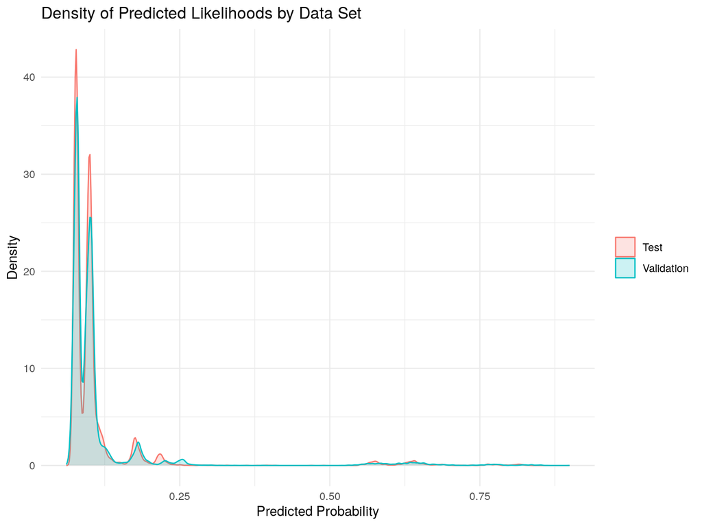

```r
# Plot comparison of predicted probability distributions
plot_predicted_probabilities_bySet(allPredProbs)
```

**Question 2:** Compare the validation and test distributions. Are they similar in shape and range? If the test distribution is shifted (e.g., toward lower or higher probabilities), what might this indicate about your model’s generalization to the test data?

## 3.2 Distribution by true outcome

Examine how well the model separates positive and negative cases in the test set.

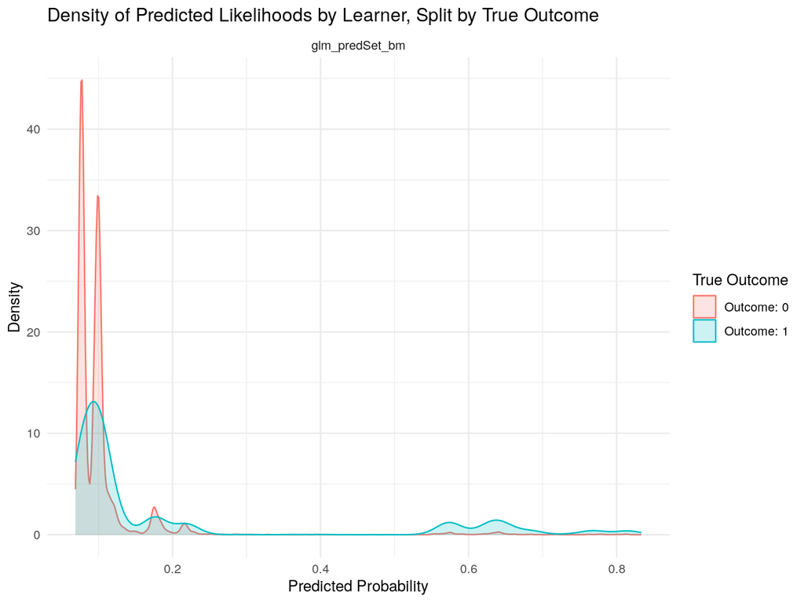

```r
# Plot test set predictions split by actual outcome
testPredProbs[[learnerSpec$outcomeName]] <- ifelse(testPredProbs[[learnerSpec$outcomeName]]==1,"yes","no")
plot_predicted_probabilities_split(testPredProbs, learnerSpec$outcomeName)
```

**Question 3:** In the test set, how well does your model separate the predicted probabilities for true positives (outcome=1) versus true negatives (outcome=0)? Is the separation comparable to what you observed in validation (Milestone 5)? If separation is worse in the test set, what might explain this degradation?

# 4. Discrimination performance

Evaluate how well your model distinguishes between classes in the test set.

## 4.1 ROC curve comparison

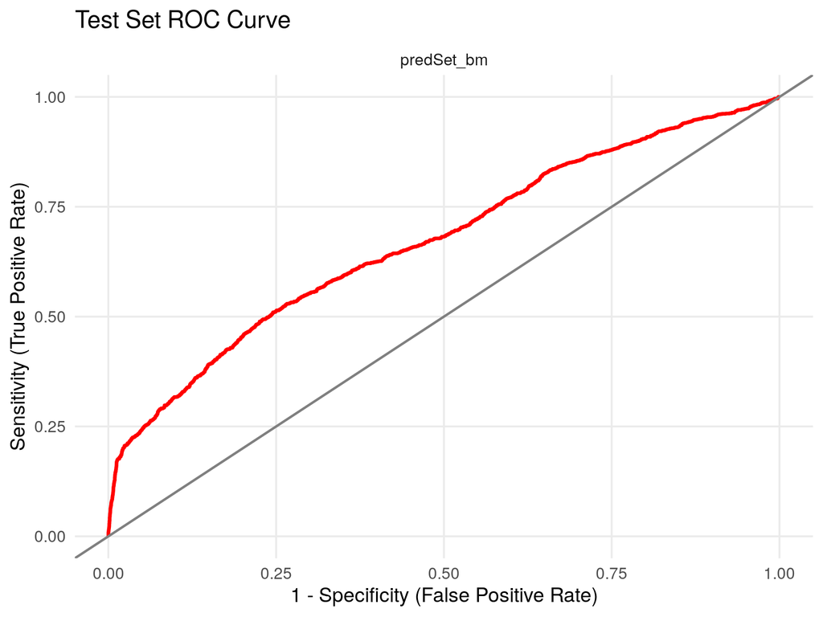

```r
# Plot ROC curve for test set
plot_roc_curve_with_reference(
  testRocResults,
  referencePredSet = unique(testRocResults$predSet),
  title = "Test Set ROC Curve"
)
```

```r
# Display ROC-AUC comparison
cat("\n=== ROC-AUC Comparison ===\n")
```

```
##
## === ROC-AUC Comparison ===
```

```r
cat("Validation ROC-AUC:",
    round(trainResults$modelResults %>%
          filter(.metric == "roc_auc") %>%
          pull(mean), 3), "\n")
```

```
## Validation ROC-AUC: 0.669
```

```r
cat("Test ROC-AUC:",
    round(testMetrics$roc_auc, 3), "\n")
```

```
## Test ROC-AUC: 0.671
```

## 4.2 Precision-Recall curve comparison

For imbalanced outcomes, PR curves provide more informative performance assessment.

[figure not shown]

```r
# Plot PR curve for test set
plot_pr_curve_with_reference(
  testPrResults,
  referencePredSet = unique(testPrResults$predSet),
  title = "Test Set Precision-Recall Curve"
)
```

```r
# Display PR-AUC comparison
cat("\n=== PR-AUC Comparison ===\n")
```

```
##
## === PR-AUC Comparison ===
```

```r
cat("Validation PR-AUC:",
    round(trainResults$modelResults %>%
          filter(.metric == "pr_auc") %>%
          pull(mean), 3), "\n")
```

```
## Validation PR-AUC: 0.311
```

```r
cat("Test PR-AUC:",
    round(testMetrics$pr_auc, 3), "\n")
```

```
## Test PR-AUC: 0.304
```

**Question 4:** Compare the discrimination metrics (ROC-AUC and PR-AUC) between validation and test sets. Is the performance drop within acceptable ranges (typically <5-10% for well-generalizing models)? Given your outcome prevalence, which metric (ROC-AUC or PR-AUC) provides a more reliable assessment of performance degradation? If you observe a large drop, what might be the causes?

# 5. Classification performance at selected thresholds

```r
# Define metric groups
rateMetrics <- c("tpr", "fpr", "tnr", "fnr")
countMetrics <- c("tpc", "fpc", "tnc", "fnc")
otherMetrics <- c("ppv", "f1", "acc")
allMetrics <- c(rateMetrics, countMetrics, otherMetrics)

# # To simplify, let's pick just one threshold and specify here
selectedThreshold <- 0.2 # @TODO edit this to match your selection (see above for what you had narrowed it to and pick one)

# Calculate test set metrics at selected thresholds
testMetricsThres <- conf_metrics_thres_learner(
  predProbs = testPredProbs,
  outcomeName = learnerSpec$outcomeName,
  thresSeq = selectedThreshold
)

# Display test metrics
cat("=== Test Set Classification Metrics ===\n\n")
```

```
## === Test Set Classification Metrics ===
```

```r
testMetricsThres %>%
  select(threshold, all_of(c("tpr", "fpr", "ppv", "f1", "acc"))) %>%
  mutate(across(where(is.numeric), ~round(., 3))) %>%
  print()
```

```
##   threshold   tpr   fpr   ppv    f1   acc
## 1       0.2 0.219 0.033 0.465 0.298 0.879
```

```r
# Compare with validation metrics
  cat("\n=== Validation vs Test Comparison ===\n")
```

```
##
## === Validation vs Test Comparison ===
```

```r
  # Get validation metrics at same threshold
  validationMetricsThres <- conf_metrics_thres_learner(
    predProbs = trainPredProbs,
    outcomeName = outcome,
    thresSeq = selectedThreshold
  )

  comparison <- data.frame(
    Metric = c("TPR", "FPR", "Precision", "F1"),
    Validation = c(
      validationMetricsThres$tpr[1],
      validationMetricsThres$fpr[1],
      validationMetricsThres$ppv[1],
      validationMetricsThres$f1[1]
    ),
    Test = c(
      testMetricsThres$tpr[1],
      testMetricsThres$fpr[1],
      testMetricsThres$ppv[1],
      testMetricsThres$f1[1]
    )
  )
  comparison$Difference <- comparison$Test - comparison$Validation
  print(comparison)
```

```
##      Metric Validation       Test    Difference
## 1       TPR 0.23446786 0.21928166 -1.518619e-02
## 2       FPR 0.03356593 0.03348084 -8.509481e-05
## 3 Precision 0.48062016 0.46461949 -1.600066e-02
## 4        F1 0.31517792 0.29794521 -1.723272e-02
```

## 5.1 Visualize classification performance

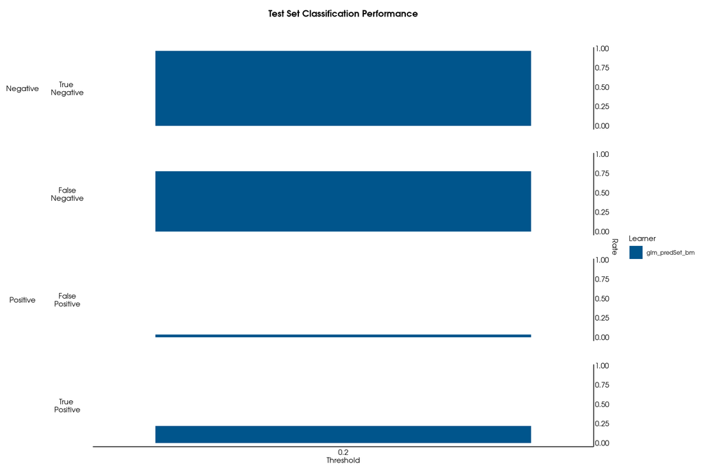

```r
# Filter and reshape data for plotting
plotData <- testMetricsThres %>%
  filter(threshold %in% selectedThreshold) %>%
  pivot_longer(
    cols = all_of(allMetrics),
    names_to = "metricType",
    values_to = "value"
  )

# Create bar plot for test set performance
conf_mat_bar_plot(
  plotData = plotData %>% filter(metricType %in% rateMetrics),
  metricType = "rate",
  outcomeDescription = c("Negative", "Positive"),  # @TODO: Update with your outcome labels
  graphTitle = "Test Set Classification Performance"
)
```

**Question 5:** Review the classification metrics at your selected threshold(s). How do key metrics compare between validation and test sets? Are the differences uniform across metrics, or do some degrade more than others? Based on these test results, would you recommend adjusting the threshold for deployment? Why or why not?

# 6. Fairness assessment on test set

Evaluate whether fairness issues observed in validation persist or change in the test set.

## 6.1 Distribution by demographic groups

```
## Assessing fairness for equity variable: age_group
```

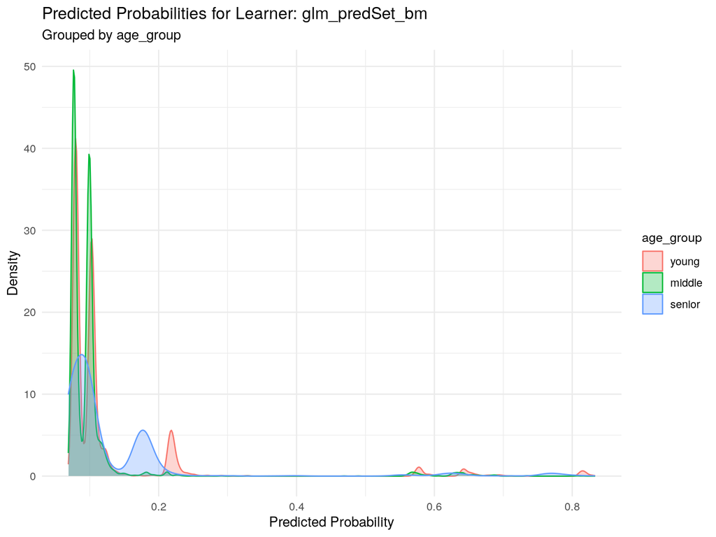

```r
# @TODO: Specify your equity variable (should match Milestone 5)
equityVar <- learnerSpec$equityVars[1]  # Use first equity variable

# Check if equity variable exists in test set
if (equityVar %in% names(testDat)) {
  # Add equity variable to predictions if not already present
  if (!(equityVar %in% names(testPredProbs))) {
    testPredProbs <- testPredProbs %>%
      bind_cols(testDat %>% select(all_of(equityVar)))
  }

  cat("Assessing fairness for equity variable:", equityVar, "\n\n")

  # Plot distribution by group
  plot_pred_probs(
    testPredProbs,
    learner = unique(testPredProbs$learnerName),
    group_var = equityVar
  )
} else {
  cat("⚠ Equity variable", equityVar, "not found in test set.\n")
}
```

**Question 6:** Compare the distribution of predicted probabilities across demographic groups in the test set. Are the patterns similar to what you observed in validation? Have disparities increased, decreased, or remained stable? What does this plot tell you? What does it indicate about fairness?

## 6.2 Classification metrics by group

```r
if (equityVar %in% names(testPredProbs)) {
  # Calculate equity metrics
  equityResults <- calc_equity_metrics_all(
    predProbs = testPredProbs,
    learnerNames = unique(testPredProbs$learnerName),
    thresholdsSelect = selectedThreshold,  # Use primary threshold
    equityVars = equityVar,
    outcomeName = outcome
  )

  # Display results
  cat("=== Test Set Fairness Metrics ===\n")
  cat("Threshold:", selectedThreshold, "\n\n")

  equityResults %>%
    select(category, tpr, fpr, ppv, fnr) %>%
    mutate(across(where(is.numeric), ~round(., 3))) %>%
    print()

  # Statistical tests for disparities
  cat("\n=== Statistical Tests for Disparities ===\n")

  equityTests <- calc_equity_tests_all(
    equityResults,
    unique(testPredProbs$learnerName),
    equityVar,
    selectedThreshold
  )

  equityTests %>%
    select(-learnerName, -threshold) %>%
    mutate(across(where(is.numeric), ~round(., 3))) %>%
    print()

  cat("\nNote: p-values < 0.05 indicate statistically significant differences between groups\n")
}
```

```
## === Test Set Fairness Metrics ===
## Threshold: 0.2
##
##   category   tpr   fpr   ppv   fnr
## 1    young 0.336 0.098 0.401 0.664
## 2   middle 0.171 0.018 0.502 0.829
## 3   senior 0.224 0.037 0.506 0.776
##
## === Statistical Tests for Disparities ===
```

```
## # A tibble: 1 × 5
## # Groups:   learnerName, equityVar [1]
##   learnerName    equityVar fnr_pVal fpr_pVal fdr_pVal
##   <chr>          <chr>        <dbl>    <dbl>    <dbl>
## 1 glm_predSet_bm age_group        0        0    0.025
##
## Note: p-values < 0.05 indicate statistically significant differences between groups
```

**Question 7:** Examine the fairness metrics and statistical tests. Which metrics show statistically significant disparities between groups? Are these disparities consistent with what you found in validation, or have they changed? What do you conclude about the extent of bias in your selected model?

# 7. Final recommendations

Based on your complete analysis across training, validation, and testing, provide your final recommendations.

**Question 8:** **Overall Performance Assessment**: Based on the test set results, does your model perform well enough for deployment in your intended use case? Consider the absolute performance metrics (not just relative to validation), the costs of different types of errors in your context, and whether the model meets minimum performance requirements you would set.

**Question 9:** **Fairness and Ethical Considerations**: Based on the fairness assessment in both validation and test sets, are there ethical concerns about deploying this model? Which groups might be advantaged or disadvantaged? What specific fairness interventions or monitoring would you recommend if this model were to be deployed? Consider both statistical fairness and practical impacts on affected populations.

**Question 10:** If recommending deployment, what conditions, monitoring, or constraints would you recommend? If not recommending deployment, what additional analyses, data collection, or model improvements would you recommend?

**Question 11:** Is your R notebook knit by following all directions clearly? Are questions answered in markdown rather than in code chunks? If formatting neat?

**@TODO: No need to answer but doublecheck!**

# 8. Save final results

Save your test results for potential future analysis or reporting.

```r
# Create final results object
finalResults <- list(
  testMetrics = testMetrics,
  testPredProbs = testPredProbs,
  testMetricsThres = testMetricsThres,
  selectedLearner = learnerName,
  selectedThreshold = selectedThreshold,
  testROC_AUC = testMetrics$roc_auc,
  testPR_AUC = testMetrics$pr_auc
)

# Add fairness results if calculated
if (exists("equityResults")) {
  finalResults$equityResults <- equityResults
  finalResults$equityTests <- equityTests
}

# Save final results
saveRDS(
  finalResults,
  file = paste0(params$my_path, "finalTestResults.rds")
)

cat("Final results saved successfully!\n")
```

```
## Final results saved successfully!
```

```r
cat("File:", paste0(params$my_path, "finalTestResults.rds"), "\n")
```

```
## File: /share/dsa495601f25/keporte2/finalTestResults.rds
```

**Congratulations!** You have completed Milestone 6 - the final testing phase of your predictive modeling project. Make sure you have:

- Answered all questions marked with @TODO
- Reviewed test performance against validation baselines
- Assessed fairness and potential biases
- Provided clear deployment recommendations
- Knitted to HTML successfully
- Saved as PDF with correct naming convention: `DSC495_601_FA25_Milestone6_unityID.pdf`

This completes your predictive modeling project pipeline from data processing through final model testing!